# Human Activity Recognition

Izaak Jephson

21/08/2020

## Introduction

Monitoring and assessing human activity automatically is a growing field as shown by the prevalence of fitness tracking apps such as Google Fit and wearable tech such as FitBit. Much of the research in this field focuses on assessing what activity is being undertaken, rather than how well it was performed. This analysis uses data from the study “Qualitative Activity Recognition of Weight Lifting Exercises”. Velloso, E.; Bulling, A.; Gellersen, H.; Ugulino, W.; Fuks, H. (2013)

In this study, six participants were asked to perform one set of 10 repetitions of the unilateral dumbbell biceps curl in five different ways, according to a specification (Class A), throwing the elbows to the front (Class B), lifting the dumbbell only halfway (Class C), lowering the dumbbell only halfway (Class D) and throwing the hips to the front (Class E).

3 models were fitted to the data in order to predict the class of exercise; a simple decision tree model, a random forest model and a bagged tree model. In each case 10-fold cross validation was used. The simple tree model performed poorly, with an out of sample error rate 0f 51%. The random forest model and bagged tree model both performed better with out-of-sample errors rates of 1% and 2% respectively, though this increased accuracy comes at the price of increased computing time and reduced interpretability.

## Data import

Firstly, the data is imported and tidied. Any variables with more than 95% missing values were discarded as these do not contain enough information to be a useful and reliable predictor.

```r
## Read in and tidy data

rawData <- read.csv(file = "data/pml-training.csv")

data <- rawData%>%
        as_tibble() %>%
        mutate_all(
                .funs = function(x)
                        replace(x, which(x == "" | x == "#DIV/0!"), NA) # manually replace missing values to ensure no useful data lost in tidying
        ) %>%
        mutate_at(vars(
                -c(X,
                   user_name,
                   cvtd_timestamp,
                   new_window,
                   num_window,
                   classe)
        ), as.numeric) %>% # convert features to numeric variables
        mutate_at("classe", as_factor) %>%
        mutate_at("cvtd_timestamp", dmy_hm) %>%
        select_if(function(x) (mean(is.na(x))) < 0.95) %>% # remove rows with no data
        select(-c("user_name",
                  "X",
                  "raw_timestamp_part_1",
                  "raw_timestamp_part_2",
                  "cvtd_timestamp",
                  "new_window",
                  "num_window"))

rawFinalTest <- read.csv(file = "data/pml-testing.csv")

finalTest <- rawFinalTest %>% # apply same tidying to testing set
        as_tibble() %>%
        mutate_all(
                .funs = function(x)
                        replace(x, which(x == "" | x == "#DIV/0!"), NA) # manually replace missing values to ensure no useful data lost in tidying
        ) %>%
        mutate_at(vars(
                -c(X,
                   user_name,
                   cvtd_timestamp,
                   new_window,
                   num_window,
                   problem_id)
        ), as.numeric) %>% # convert features to numeric variables
        mutate_at("cvtd_timestamp", dmy_hm) %>%
        select_if(function(x) (mean(is.na(x))) < 0.95)
```

## Inital data exploration and variable selection

In the data, there are 19622 observations and 53 variables. the variable that we are interested in predicting is the “classe” variable, which is a factor variable with 5 levels (A, B, C, D, E), each of which represents a different way in which the exercise was performed. A test for Variables with near zero variance was carried out to determine whether any variables can be discarded. All variables showed an adequate degree of variance to be included in the analysis.

The data was divided into a training and test set, with the ratio 80:20. The test set was set aside for later use in determining the out-of-sample error rate for each model.

```r
# Create data partition and split data into training and test data in order to be able to estimate out of sample error

inTrain <- data %>% pull(classe) %>% createDataPartition(p = 0.80, list = FALSE)

training <- data %>% slice(inTrain)
testing <- data %>% slice(-inTrain)

nearZeroVar(training, saveMetrics = TRUE)
```

```
##                      freqRatio percentUnique zeroVar   nzv
## roll_belt             1.091794    7.52914198   FALSE FALSE
## pitch_belt            1.045161   11.12172750   FALSE FALSE
## yaw_belt              1.085919   11.78419008   FALSE FALSE
## total_accel_belt      1.055708    0.17835531   FALSE FALSE
## gyros_belt_x          1.012456    0.85355755   FALSE FALSE
## gyros_belt_y          1.152795    0.42677878   FALSE FALSE
## gyros_belt_z          1.091106    1.05739219   FALSE FALSE
## accel_belt_x          1.089431    1.03828269   FALSE FALSE
## accel_belt_y          1.140234    0.89177655   FALSE FALSE
## accel_belt_z          1.053597    1.86636091   FALSE FALSE
## magnet_belt_x         1.048611    1.96190840   FALSE FALSE
## magnet_belt_y         1.087379    1.86636091   FALSE FALSE
## magnet_belt_z         1.042667    2.80909612   FALSE FALSE
## roll_arm             51.055556   15.98190968   FALSE FALSE
## pitch_arm            86.187500   18.46614434   FALSE FALSE
## yaw_arm              32.821429   17.37053315   FALSE FALSE
## total_accel_arm       1.023644    0.42040894   FALSE FALSE
## gyros_arm_x           1.078818    4.05758329   FALSE FALSE
## gyros_arm_y           1.459716    2.35683802   FALSE FALSE
## gyros_arm_z           1.148780    1.52238996   FALSE FALSE
## accel_arm_x           1.015038    4.91751067   FALSE FALSE
## accel_arm_y           1.171598    3.38238104   FALSE FALSE
## accel_arm_z           1.057143    4.94299000   FALSE FALSE
## magnet_arm_x          1.014706    8.49098669   FALSE FALSE
## magnet_arm_y          1.130435    5.51627492   FALSE FALSE
## magnet_arm_z          1.043956    8.02598892   FALSE FALSE
## roll_dumbbell         1.017699   85.83986241   FALSE FALSE
## pitch_dumbbell        2.243478   83.43843557   FALSE FALSE
## yaw_dumbbell          1.223404   84.94808587   FALSE FALSE
## total_accel_dumbbell  1.076568    0.27390280   FALSE FALSE
## gyros_dumbbell_x      1.018595    1.50328046   FALSE FALSE
## gyros_dumbbell_y      1.254777    1.72622460   FALSE FALSE
## gyros_dumbbell_z      1.107527    1.27396649   FALSE FALSE
## accel_dumbbell_x      1.088803    2.66258997   FALSE FALSE
## accel_dumbbell_y      1.009804    2.91738327   FALSE FALSE
## accel_dumbbell_z      1.143617    2.58615198   FALSE FALSE
## magnet_dumbbell_x     1.014085    6.93037773   FALSE FALSE
## magnet_dumbbell_y     1.186667    5.27422129   FALSE FALSE
## magnet_dumbbell_z     1.026490    4.25504809   FALSE FALSE
## roll_forearm         11.242754   12.71418562   FALSE FALSE
## pitch_forearm        64.645833   17.51703930   FALSE FALSE
## yaw_forearm          15.907692   11.71412192   FALSE FALSE
## total_accel_forearm   1.130699    0.44588827   FALSE FALSE
## gyros_forearm_x       1.037383    1.83451175   FALSE FALSE
## gyros_forearm_y       1.032468    4.64997771   FALSE FALSE
## gyros_forearm_z       1.155080    1.88547041   FALSE FALSE
## accel_forearm_x       1.026316    4.96209950   FALSE FALSE
## accel_forearm_y       1.186667    6.32524365   FALSE FALSE
## accel_forearm_z       1.015748    3.60532518   FALSE FALSE
## magnet_forearm_x      1.000000    9.42098223   FALSE FALSE
## magnet_forearm_y      1.292308   11.75871075   FALSE FALSE
## magnet_forearm_z      1.041667   10.42104593   FALSE FALSE
## classe                1.469388    0.03184916   FALSE FALSE
```

## Model fitting

### Decision tree

The aim of our target model is to use the features in the data to predict the class of exercise (the “classe” variable). As the class is a categoric variable, a good model to start with might be a decision tree. This model has the advantage of being simple to interpret.

A decision tree model was fit to the data, using 10 fold cross-validation. The resulting model is show below.

```r
# Fit a decision tree to the data

set.seed(2572)

tic("decision tree")

model1 <- train(classe ~ ., data = training, na.action = na.pass, method = "rpart", trControl = trainControl(method = "cv", number = 10))

toc()
```

```
## decision tree: 7.39 sec elapsed
```

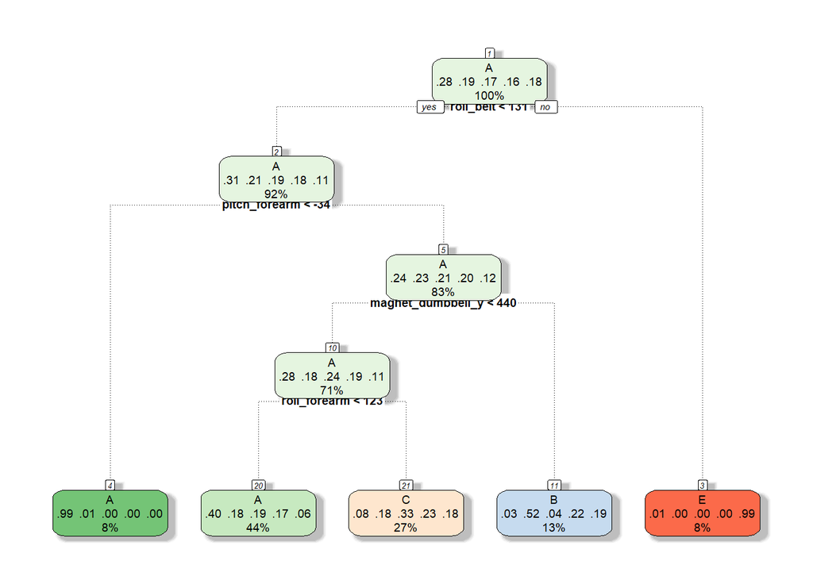

```r
fancyRpartPlot(model1$finalModel, cex = 0.6, sub = "")
```

```r
predict1 <- predict(model1, testing)

confMat1 <- confusionMatrix(testing %>% pull(classe), predict1)
```

The accuracy of the decision tree model on the test set is 49% and the out of sample error rate is 51%.

### Random forest

As the decision tree had a poor accuracy, a more complex model might be a better fit to the data. A random forest model was fitted to the data using 10-fold cross validation.

```r
set.seed(591)

tic("random forest")

model2 <- train(classe ~ ., data = training, na.action = na.pass, method = "rf", trControl = trainControl(method = "cv", number = 10))

toc()
```

```
## random forest: 1163.14 sec elapsed
```

```r
predict2 <- predict(model2, testing)

confMat2 <- confusionMatrix(testing %>% pull(classe), predict2)
```

The accuracy of the random forest model on the test set is 99% and the out of sample error rate is 1%

### Bagged tree

An alternative the the random forest model is the bagged tree model. A bagged tree model was fitted to the data using 10-fold cross validation.

```r
set.seed(70333)

tic("bagged tree")

model3 <- train(classe ~ ., data = training, na.action = na.omit, method = "treebag", trControl = trainControl(method = "cv", number = 10))

toc()
```

```
## bagged tree: 108.62 sec elapsed
```

```r
predict3 <- predict(model3, testing)

confMat3 <- confusionMatrix(testing %>% pull(classe), predict3)
```

The accuracy of the bagged tree model on the test set is 98% and the out of sample error rate is 2%

## Conclusions

The random forest and bagged tree models both perform very well on this data set, with very low out-of-sample error rates. A simple decision tree model does not appear to be sufficient in sorting the classes of exercises, as the error rate of 51% is very high.

However, the drawback of the more complex models is that they require much longer to fit. The decision tree is very quick to fit at only 7 seconds, while the bagged tree model takes almost 2 minutes to fit and the random forest model takes around 19 minutes to fit.

On balance, if computing resources are not an issue, then the random model provides the best accuracy in this case, but the bagged tree model provides a balance between high accuracy and high speed of fitting.

## References

Velloso, E.; Bulling, A.; Gellersen, H.; Ugulino, W.; Fuks, H. 2013. *Qualitative Activity Recognition of Weight Lifting Exercises*. Stuttgart, Germany: Proceedings of 4th International Conference in Cooperation with SIGCHI (Augmented Human ’13). http:/groupware.les.inf.puc-rio.br/har#ixzz4Tk2YB4Ft.